# Assignment4

## **Load Libraries**

```r
library(readr)
library(factoextra)
library(flexclust)
library(tidyverse)
library(caret)
```

```r
library(dplyr)
library(ggplot2)
```

## **Import Data**

```r
Pharmaceuticals <- read_csv("Pharmaceuticals.csv")
```

*Data sourced from Canvas.*

## **Numerical Variables Only**

```r
sapply(Pharmaceuticals, class)
```

```
##                Symbol                  Name            Market_Cap
##           "character"           "character"             "numeric"
##                  Beta              PE_Ratio                   ROE
##             "numeric"             "numeric"             "numeric"
##                   ROA        Asset_Turnover              Leverage
##             "numeric"             "numeric"             "numeric"
##            Rev_Growth     Net_Profit_Margin Median_Recommendation
##             "numeric"             "numeric"           "character"
##              Location              Exchange
##           "character"           "character"
```

```r
Pharmaceuticals_Num <- Pharmaceuticals[,3:11]
sapply(Pharmaceuticals_Num, class)
```

```
##        Market_Cap              Beta          PE_Ratio               ROE
##         "numeric"         "numeric"         "numeric"         "numeric"
##               ROA    Asset_Turnover          Leverage        Rev_Growth
##         "numeric"         "numeric"         "numeric"         "numeric"
## Net_Profit_Margin
##         "numeric"
```

## **Normalize Data**

```r
set.seed(123)
summary(Pharmaceuticals_Num)
```

```
##    Market_Cap          Beta           PE_Ratio          ROE
##  Min.   :  0.41   Min.   :0.1800   Min.   : 3.60   Min.   : 3.9
##  1st Qu.:  6.30   1st Qu.:0.3500   1st Qu.:18.90   1st Qu.:14.9
##  Median : 48.19   Median :0.4600   Median :21.50   Median :22.6
##  Mean   : 57.65   Mean   :0.5257   Mean   :25.46   Mean   :25.8
##  3rd Qu.: 73.84   3rd Qu.:0.6500   3rd Qu.:27.90   3rd Qu.:31.0
##  Max.   :199.47   Max.   :1.1100   Max.   :82.50   Max.   :62.9
##       ROA        Asset_Turnover    Leverage        Rev_Growth
##  Min.   : 1.40   Min.   :0.3    Min.   :0.0000   Min.   :-3.17
##  1st Qu.: 5.70   1st Qu.:0.6    1st Qu.:0.1600   1st Qu.: 6.38
##  Median :11.20   Median :0.6    Median :0.3400   Median : 9.37
##  Mean   :10.51   Mean   :0.7    Mean   :0.5857   Mean   :13.37
##  3rd Qu.:15.00   3rd Qu.:0.9    3rd Qu.:0.6000   3rd Qu.:21.87
##  Max.   :20.30   Max.   :1.1    Max.   :3.5100   Max.   :34.21
##  Net_Profit_Margin
##  Min.   : 2.6
##  1st Qu.:11.2
##  Median :16.1
##  Mean   :15.7
##  3rd Qu.:21.1
##  Max.   :25.5
```

```r
norm_model <- preProcess(Pharmaceuticals_Num, method = c("center", "scale"))
Pharmaceuticals_Norm <- predict(norm_model,Pharmaceuticals_Num)
summary(Pharmaceuticals_Norm)
```

```
##    Market_Cap           Beta            PE_Ratio            ROE
##  Min.   :-0.9768   Min.   :-1.3466   Min.   :-1.3404   Min.   :-1.4515
##  1st Qu.:-0.8763   1st Qu.:-0.6844   1st Qu.:-0.4023   1st Qu.:-0.7223
##  Median :-0.1614   Median :-0.2560   Median :-0.2429   Median :-0.2118
##  Mean   : 0.0000   Mean   : 0.0000   Mean   : 0.0000   Mean   : 0.0000
##  3rd Qu.: 0.2762   3rd Qu.: 0.4841   3rd Qu.: 0.1495   3rd Qu.: 0.3450
##  Max.   : 2.4200   Max.   : 2.2758   Max.   : 3.4971   Max.   : 2.4597
##       ROA          Asset_Turnover       Leverage          Rev_Growth
##  Min.   :-1.7128   Min.   :-1.8451   Min.   :-0.74966   Min.   :-1.4971
##  1st Qu.:-0.9047   1st Qu.:-0.4613   1st Qu.:-0.54487   1st Qu.:-0.6328
##  Median : 0.1289   Median :-0.4613   Median :-0.31449   Median :-0.3621
##  Mean   : 0.0000   Mean   : 0.0000   Mean   : 0.00000   Mean   : 0.0000
##  3rd Qu.: 0.8430   3rd Qu.: 0.9225   3rd Qu.: 0.01828   3rd Qu.: 0.7693
##  Max.   : 1.8389   Max.   : 1.8451   Max.   : 3.74280   Max.   : 1.8862
##  Net_Profit_Margin
##  Min.   :-1.99560
##  1st Qu.:-0.68504
##  Median : 0.06168
##  Mean   : 0.00000
##  3rd Qu.: 0.82364
##  Max.   : 1.49416
```

## **Finding K**

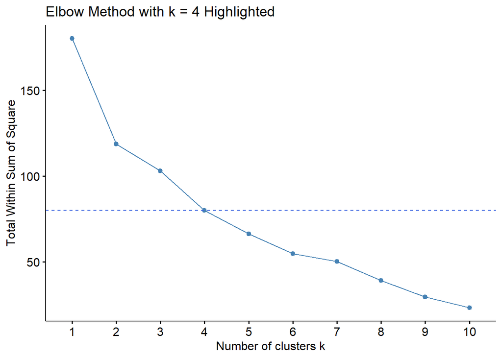

```r
fviz_nbclust(Pharmaceuticals_Norm, kmeans, method = "wss") +
  geom_hline(yintercept = 80, linetype = 2, color = "royalblue", size = 0.5) +
  ggtitle("Elbow Method with k = 4 Highlighted")
```

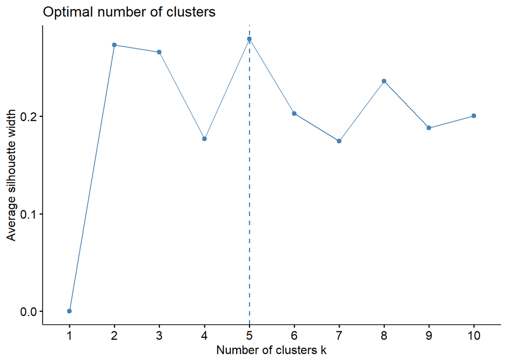

```r
fviz_nbclust(Pharmaceuticals_Norm, kmeans, method = "silhouette")
```

## **Clustering**

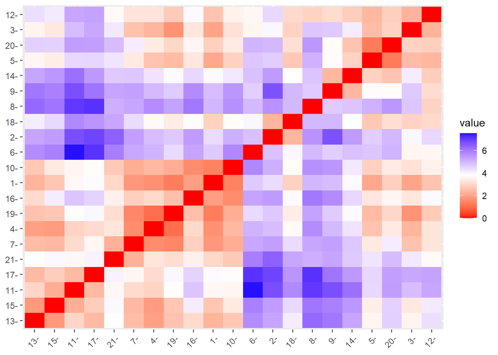

```r
distance <- get_dist(Pharmaceuticals_Norm)
fviz_dist(distance)
```

```r
Pharmaceuticals_Clusters <- kmeans(Pharmaceuticals_Norm, centers = 4, nstart = 25)
Pharmaceuticals_Clusters$centers
```

```
##    Market_Cap       Beta   PE_Ratio        ROE        ROA Asset_Turnover
## 1  1.69558112 -0.1780563 -0.1984582  1.2349879  1.3503431   1.153164e+00
## 2 -0.52462814  0.4451409  1.8498439 -1.0404550 -1.1865838   1.480297e-16
## 3 -0.82617719  0.4775991 -0.3696184 -0.5631589 -0.8514589  -9.994088e-01
## 4 -0.03142211 -0.4360989 -0.3172485  0.1950459  0.4083915   1.729746e-01
##     Leverage Rev_Growth Net_Profit_Margin
## 1 -0.4680782  0.4671788         0.5912425
## 2 -0.3443544 -0.5769454        -1.6095439
## 3  0.8502201  0.9158889        -0.3319956
## 4 -0.2744931 -0.7041516         0.5569544
```

```r
Pharmaceuticals_Clusters$size
```

```
## [1] 4 3 6 8
```

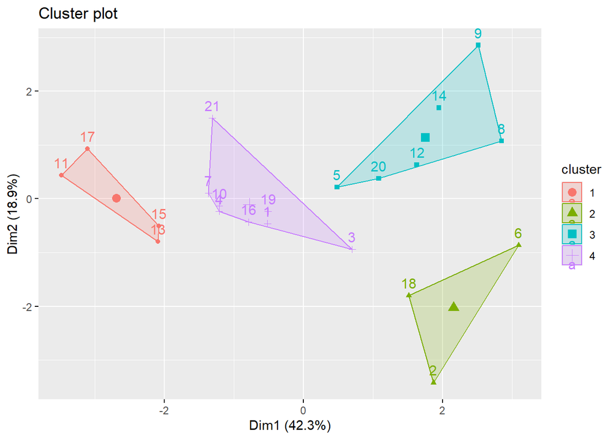

```r
fviz_cluster(Pharmaceuticals_Clusters, data = Pharmaceuticals_Norm)
```

# **Question A:**

## **Justification of Choices**

#### - Normalization:

I chose to use z-score (“center” and “scale”) because the numerical variables have very different magnitudes and is recommended for k-means.

#### - Distance Metric:

I chose to use Euclidean because it works well when variables are standardized and is recommended for k-means.

#### - Clustering Algorithm:

I chose to use kmeans() and not kcca because we are using numerical variables only and are using euclidean distance.

#### - Number of Clusters:

I chose 4 by using the “wss” method because the plot shows a clear bend at k = 4 and the shapes of the clusters in k = 4 logically fits the data more than k = 5 from the “silhouette” method.

## **Cluster Interpretation for Numerical Variable**

```r
Pharmaceuticals_Num_Clusters <- Pharmaceuticals[,3:11]
Pharmaceuticals_Num_Clusters$Cluster <- Pharmaceuticals_Clusters$cluster

Clusters <- split(Pharmaceuticals_Num_Clusters, Pharmaceuticals_Num_Clusters$Cluster)

print(Clusters)
```

```
## $`1`
## # A tibble: 4 × 10
##   Market_Cap  Beta PE_Ratio   ROE   ROA Asset_Turnover Leverage Rev_Growth
##        <dbl> <dbl>    <dbl> <dbl> <dbl>          <dbl>    <dbl>      <dbl>
## 1       122.  0.35     18    62.9  20.3            1       0.34      21.9
## 2       174.  0.46     28.4  28.6  16.3            0.9     0.1        9.37
## 3       133.  0.46     18.9  40.6  15              1.1     0.28      17.4
## 4       199.  0.65     23.6  45.6  19.2            0.8     0.16      25.5
## # ℹ 2 more variables: Net_Profit_Margin <dbl>, Cluster <int>
##
## $`2`
## # A tibble: 3 × 10
##   Market_Cap  Beta PE_Ratio   ROE   ROA Asset_Turnover Leverage Rev_Growth
##        <dbl> <dbl>    <dbl> <dbl> <dbl>          <dbl>    <dbl>      <dbl>
## 1       7.58  0.41     82.5  12.9   5.5            0.9     0.6        9.16
## 2      16.9   1.11     27.9   3.9   1.4            0.6     0         -3.17
## 3      56.2   0.4      56.5  13.5   5.7            0.6     0.35      15
## # ℹ 2 more variables: Net_Profit_Margin <dbl>, Cluster <int>
##
## $`3`
## # A tibble: 6 × 10
##   Market_Cap  Beta PE_Ratio   ROE   ROA Asset_Turnover Leverage Rev_Growth
##        <dbl> <dbl>    <dbl> <dbl> <dbl>          <dbl>    <dbl>      <dbl>
## 1      47.2   0.32     20.1  21.8   7.5            0.6     0.34      26.8
## 2       0.41  0.85     26    24.1   4.3            0.6     3.51       6.38
## 3       0.78  1.08      3.6  15.1   5.1            0.3     1.07      34.2
## 4       2.6   0.65     19.9  21.4   6.8            0.6     1.45      14.0
## 5       1.2   0.75     28.6  11.2   5.4            0.3     0.93      30.4
## 6       3.26  0.24     18.4  10.2   6.8            0.5     0.2       29.2
## # ℹ 2 more variables: Net_Profit_Margin <dbl>, Cluster <int>
##
## $`4`
## # A tibble: 8 × 10
##   Market_Cap  Beta PE_Ratio   ROE   ROA Asset_Turnover Leverage Rev_Growth
##        <dbl> <dbl>    <dbl> <dbl> <dbl>          <dbl>    <dbl>      <dbl>
## 1       68.4  0.32     24.7  26.4  11.8            0.7     0.42       7.54
## 2        6.3  0.46     20.7  14.9   7.8            0.9     0.27       7.05
## 3       67.6  0.52     21.5  27.4  15.4            0.9     0         15
## 4       51.3  0.5      13.9  34.8  15.1            0.9     0.57       2.7
## 5       73.8  0.18     27.9  31    13.5            0.6     0.53       6.21
## 6       96.6  0.19     21.6  17.9  11.2            0.5     0.06      -2.69
## 7       34.1  0.51     18.9  22.6  13.3            0.8     0          8.56
## 8       48.2  0.63     13.1  54.9  13.4            0.6     1.12       0.36
## # ℹ 2 more variables: Net_Profit_Margin <dbl>, Cluster <int>
```

### Market_Cap by Cluster

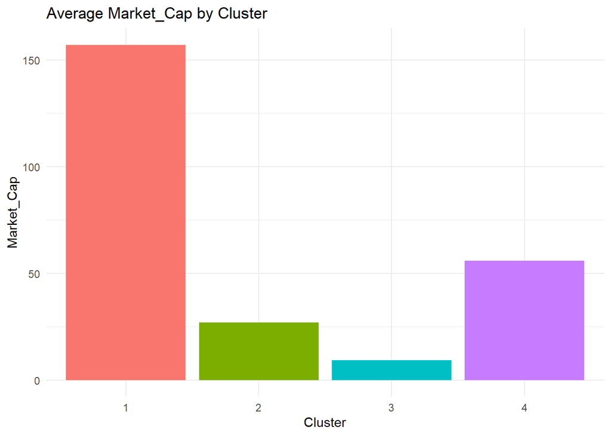

```r
ggplot(Pharmaceuticals_Num_Clusters, aes(x = factor(Cluster), y = Market_Cap, fill = factor(Cluster))) +
  geom_bar(stat = "summary", fun = "mean") +
  labs(title = "Average Market_Cap by Cluster", x = "Cluster", y = "Market_Cap") +
  theme_minimal() +
  theme(legend.position = "none")
```

### Beta by Cluster

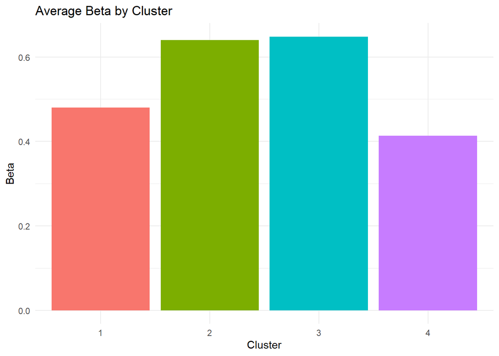

```r
ggplot(Pharmaceuticals_Num_Clusters, aes(x = factor(Cluster), y = Beta, fill = factor(Cluster))) +
  geom_bar(stat = "summary", fun = "mean") +
  labs(title = "Average Beta by Cluster", x = "Cluster", y = "Beta") +
  theme_minimal() +
  theme(legend.position = "none")
```

### PE_Ratio by Cluster

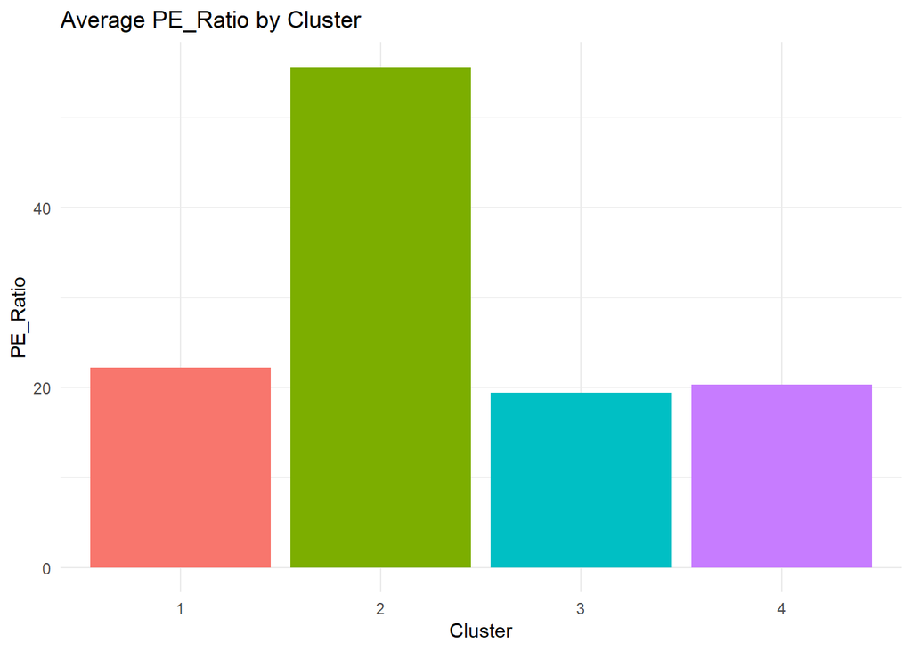

```r
ggplot(Pharmaceuticals_Num_Clusters, aes(x = factor(Cluster), y = PE_Ratio, fill = factor(Cluster))) +
  geom_bar(stat = "summary", fun = "mean") +
  labs(title = "Average PE_Ratio by Cluster", x = "Cluster", y = "PE_Ratio") +
  theme_minimal() +
  theme(legend.position = "none")
```

### ROE by Cluster

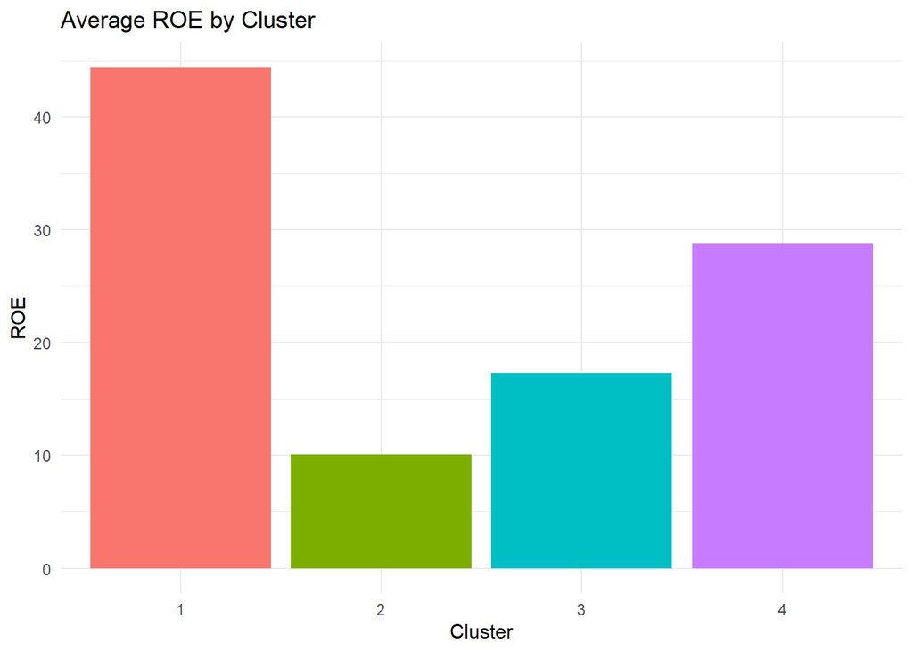

```r
ggplot(Pharmaceuticals_Num_Clusters, aes(x = factor(Cluster), y = ROE, fill = factor(Cluster))) +
  geom_bar(stat = "summary", fun = "mean") +
  labs(title = "Average ROE by Cluster", x = "Cluster", y = "ROE") +
  theme_minimal() +
  theme(legend.position = "none")
```

### ROA by Cluster

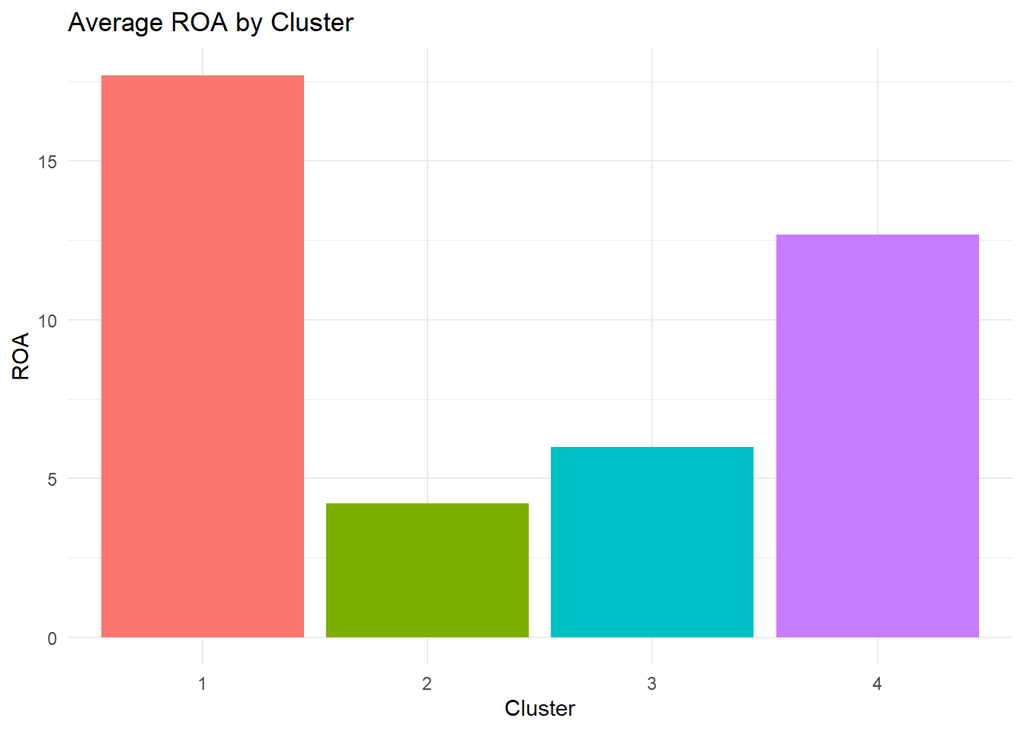

```r
ggplot(Pharmaceuticals_Num_Clusters, aes(x = factor(Cluster), y = ROA, fill = factor(Cluster))) +
  geom_bar(stat = "summary", fun = "mean") +
  labs(title = "Average ROA by Cluster", x = "Cluster", y = "ROA") +
  theme_minimal() +
  theme(legend.position = "none")
```

### Asset_Turnover by Cluster

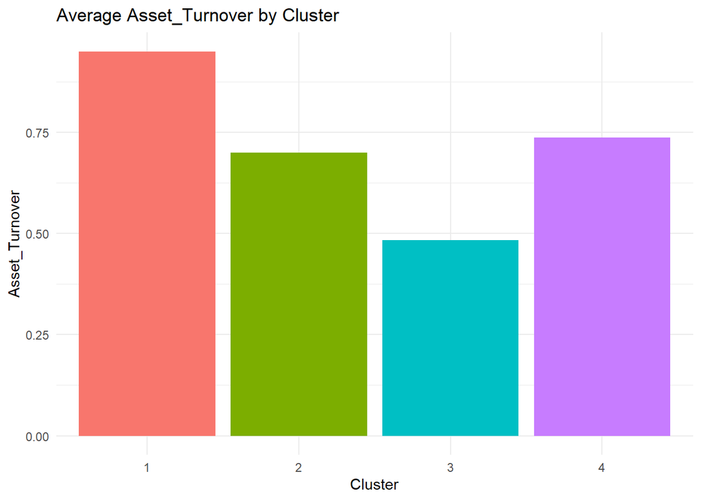

```r
ggplot(Pharmaceuticals_Num_Clusters, aes(x = factor(Cluster), y = Asset_Turnover, fill = factor(Cluster))) +
  geom_bar(stat = "summary", fun = "mean") +
  labs(title = "Average Asset_Turnover by Cluster", x = "Cluster", y = "Asset_Turnover") +
  theme_minimal() +
  theme(legend.position = "none")
```

### Leverage by Cluster

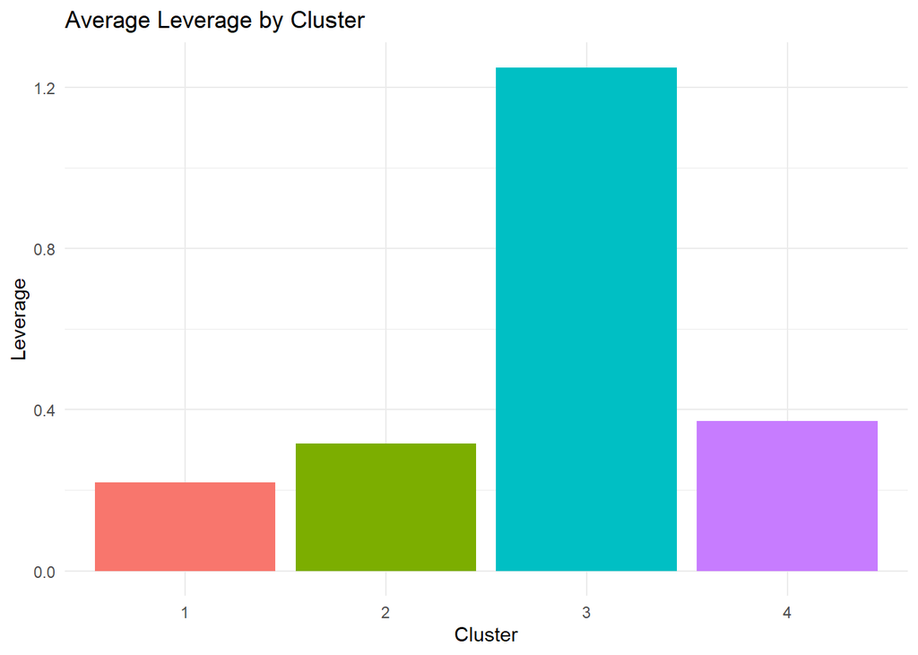

```r
ggplot(Pharmaceuticals_Num_Clusters, aes(x = factor(Cluster), y = Leverage, fill = factor(Cluster))) +
  geom_bar(stat = "summary", fun = "mean") +
  labs(title = "Average Leverage by Cluster", x = "Cluster", y = "Leverage") +
  theme_minimal() +
  theme(legend.position = "none")
```

### Rev_Growth by Cluster

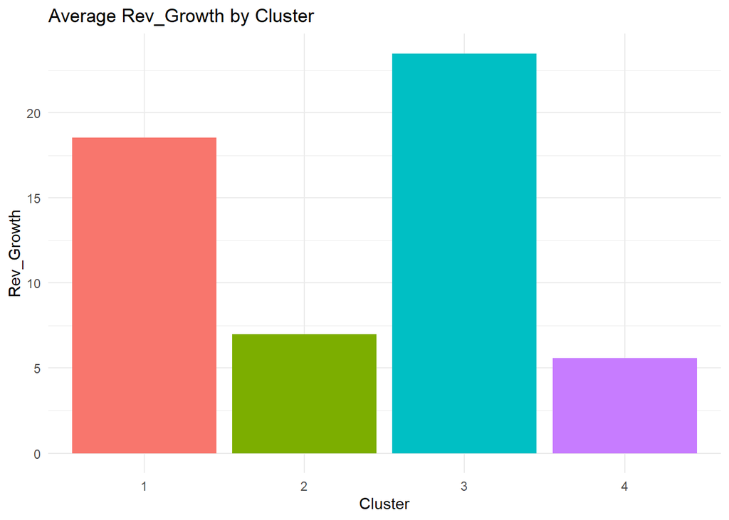

```r
ggplot(Pharmaceuticals_Num_Clusters, aes(x = factor(Cluster), y = Rev_Growth, fill = factor(Cluster))) +
  geom_bar(stat = "summary", fun = "mean") +
  labs(title = "Average Rev_Growth by Cluster", x = "Cluster", y = "Rev_Growth") +
  theme_minimal() +
  theme(legend.position = "none")
```

### Net_Profit_Margin by Cluster

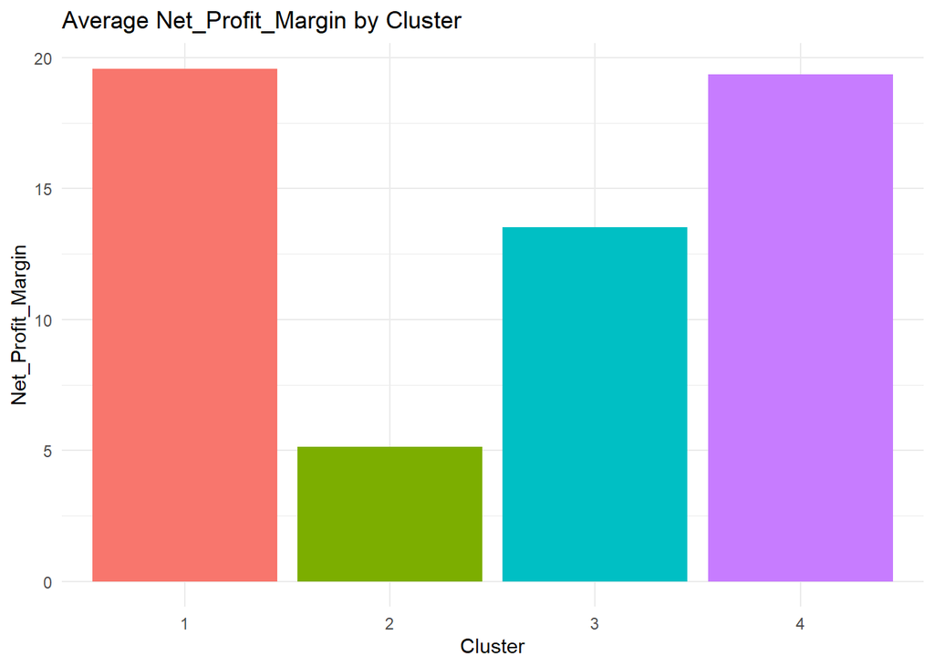

```r
ggplot(Pharmaceuticals_Num_Clusters, aes(x = factor(Cluster), y = Net_Profit_Margin, fill = factor(Cluster))) +
  geom_bar(stat = "summary", fun = "mean") +
  labs(title = "Average Net_Profit_Margin by Cluster", x = "Cluster", y = "Net_Profit_Margin") +
  theme_minimal() +
  theme(legend.position = "none")
```

# **Question B:**

### **Interpretation**

#### Cluster 1:

- Has the highest average Market Cap
- Has the highest average ROE
- Has the highest average ROA
- Has the highest average Net Profit Margin
- Has the least average Leverage

Interpretation: Stable, efficient and highly profitable

#### Cluster 2:

- Has the highest average PE Ratio
- Has high average Beta
- Has low average Leverage
- Has low average Rev Growth
- Has the least average ROE
- Has the least average ROA
- Has the least average Net Profit Margin

Interpretation: Low Growth, not very efficient, and not very profitable

#### Cluster 3:

- Has the highest average Beta
- Has the highest average Leverage
- Has the highest average Rev Growth
- Has low average ROE
- Has low average ROA
- Has the least average Market Cap
- Has the least average Asset Turnover

Interpretation: Growing, not very efficient, and less profitable

#### Cluster 4:

- Has high average Net Profit Margin
- Has low average Leverage
- Has the least average Beta
- Has the least average Rev Growth

Interpretation: Stable, efficient, and profitable

## **Cluster Interpretation for Categorical Variable**

```r
Pharmaceuticals_Clusters$cluster
```

```
##  [1] 4 2 4 4 3 2 4 3 3 4 1 3 1 3 1 4 1 2 4 3 4
```

```r
Pharmaceuticals_Interp <- Pharmaceuticals[,-(3:11)]
Pharmaceuticals_Interp$Cluster <- Pharmaceuticals_Clusters$cluster

Clusters <- split(Pharmaceuticals_Interp, Pharmaceuticals_Interp$Cluster)

print(Clusters)
```

```
## $`1`
## # A tibble: 4 × 6
##   Symbol Name                Median_Recommendation Location Exchange Cluster
##   <chr>  <chr>               <chr>                 <chr>    <chr>      <int>
## 1 GSK    GlaxoSmithKline plc Hold                  UK       NYSE           1
## 2 JNJ    Johnson & Johnson   Moderate Buy          US       NYSE           1
## 3 MRK    Merck & Co., Inc.   Hold                  US       NYSE           1
## 4 PFE    Pfizer Inc          Moderate Buy          US       NYSE           1
##
## $`2`
## # A tibble: 3 × 6
##   Symbol Name                  Median_Recommendation Location Exchange Cluster
##   <chr>  <chr>                 <chr>                 <chr>    <chr>      <int>
## 1 AGN    Allergan, Inc.        Moderate Buy          CANADA   NYSE           2
## 2 BAY    Bayer AG              Hold                  GERMANY  NYSE           2
## 3 PHA    Pharmacia Corporation Hold                  US       NYSE           2
##
## $`3`
## # A tibble: 6 × 6
##   Symbol Name                    Median_Recommendation Location Exchange Cluster
##   <chr>  <chr>                   <chr>                 <chr>    <chr>      <int>
## 1 AVE    Aventis                 Moderate Buy          FRANCE   NYSE           3
## 2 CHTT   Chattem, Inc            Moderate Buy          US       NASDAQ         3
## 3 ELN    Elan Corporation, plc   Moderate Sell         IRELAND  NYSE           3
## 4 IVX    IVAX Corporation        Hold                  US       AMEX           3
## 5 MRX    Medicis Pharmaceutical… Moderate Buy          US       NYSE           3
## 6 WPI    Watson Pharmaceuticals… Moderate Sell         US       NYSE           3
##
## $`4`
## # A tibble: 8 × 6
##   Symbol Name                    Median_Recommendation Location Exchange Cluster
##   <chr>  <chr>                   <chr>                 <chr>    <chr>      <int>
## 1 ABT    Abbott Laboratories     Moderate Buy          US       NYSE           4
## 2 AHM    Amersham plc            Strong Buy            UK       NYSE           4
## 3 AZN    AstraZeneca PLC         Moderate Sell         UK       NYSE           4
## 4 BMY    Bristol-Myers Squibb C… Moderate Sell         US       NYSE           4
## 5 LLY    Eli Lilly and Company   Hold                  US       NYSE           4
## 6 NVS    Novartis AG             Hold                  SWITZER… NYSE           4
## 7 SGP    Schering-Plough Corpor… Hold                  US       NYSE           4
## 8 WYE    Wyeth                   Hold                  US       NYSE           4
```

### Median Recommendation by Cluster

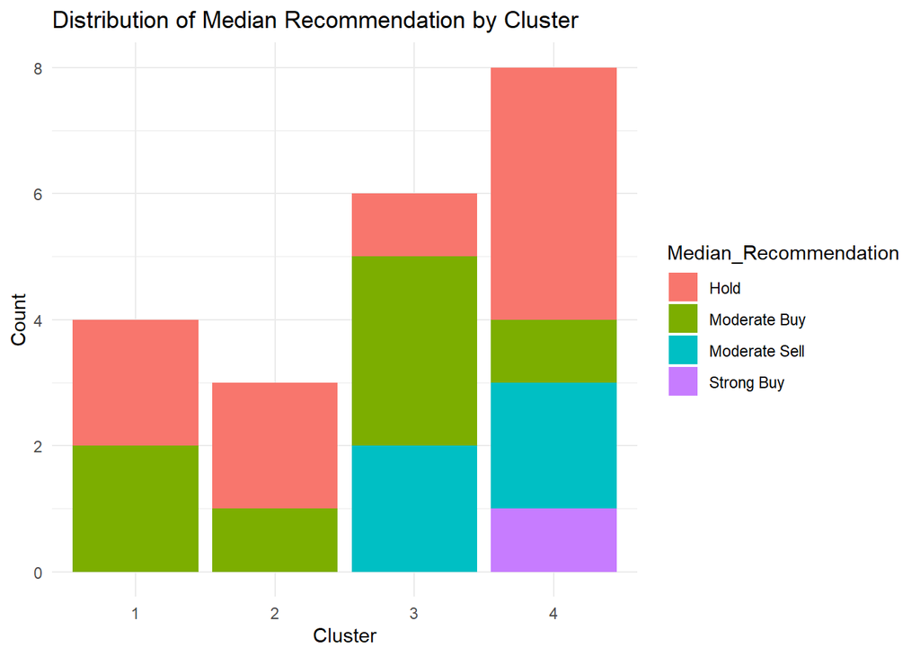

```r
ggplot(Pharmaceuticals_Interp, aes(x = factor(Cluster), fill = Median_Recommendation)) +
  geom_bar() +
  labs(title = "Distribution of Median Recommendation by Cluster", x = "Cluster", y = "Count") +
  theme_minimal()
```

### Location by Cluster

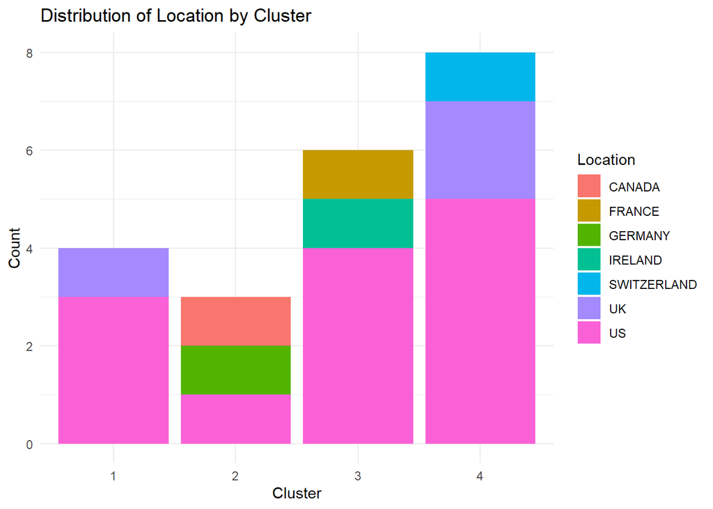

```r
ggplot(Pharmaceuticals_Interp, aes(x = factor(Cluster), fill = Location)) +
  geom_bar() +
  labs(title = "Distribution of Location by Cluster", x = "Cluster", y = "Count") +
  theme_minimal()
```

### Exchange by Cluster

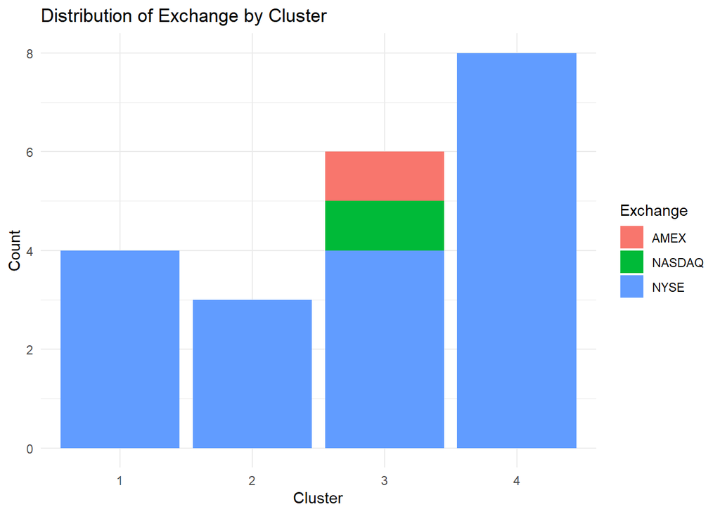

```r
ggplot(Pharmaceuticals_Interp, aes(x = factor(Cluster), fill = Exchange)) +
  geom_bar() +
  labs(title = "Distribution of Exchange by Cluster", x = "Cluster", y = "Count") +
  theme_minimal()
```

# **Question C:**

### **Interpretation**

#### Cluster 1:

- Has no Sells
- Mostly USA
- All NYSE

#### Cluster 2:

- Has no Sells
- Has least USA
- All NYSE

#### Cluster 3:

- Has the highest amount of Moderate Buys
- Mostly USA
- Has AMEX
- Has NASDAQ

#### Cluster 4:

- Has the highest amount of Holds
- Has Strong Buys
- Mostly USA
- All NYSE

#### Overall Interpretation:

There is not many strong patterns in the categorical values. Mostly due to them not being used in the formation of the clusters. The Median Recommendation slightly reflects the stability and growth found in the numerical interpretation. Cluster 3 is the only cluster with data outside the NYSE.

# **Question D:**

## **Cluster Names**

#### - Cluster 1: Strong Earners

#### - Cluster 2: Weak Earners

#### - Cluster 3: Growing Earners

#### - Cluster 4: Stable Earners

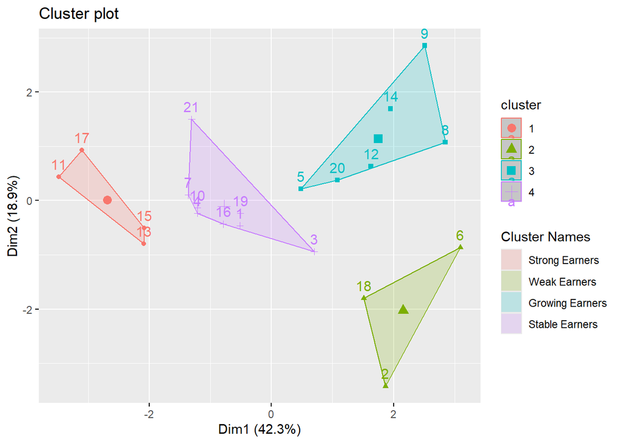

```r
Cluster_Names <- c("Strong Earners", "Weak Earners", "Growing Earners", "Stable Earners")
fviz_cluster(Pharmaceuticals_Clusters, data = Pharmaceuticals_Norm) +
  scale_fill_discrete(name = "Cluster Names", labels = Cluster_Names)
```